# desktop-Copy1

## Data Overview

The digital mammography dataset used includes data derived from a random sample of 20,000 digital and 20,000 film-screen mammograms performed between January 2005 and December 2008 from women in the Breast Cancer Surveillance Consortium.

### Explanation of DataSet

1.**age_c**: patient's age in years at time of mammogram

2.**assess_c**: Radiologist's assessment based on the BI-RADS scale *(0 = Needs additional imaging, 1 = Negative, 2 = Benign, finding(s), 3 = Probably benign, 4 = Suspicious abnormality, 5 = Highly suggestive of malignancy)*

3.**cancer_c**: binary indicator of cancer diagnosis within one year of screening mammogram *(0 = no cancer diagnosis, 1 = cancer diagnosis)*

4.**compfilm_c**: comparison mammogram from prior mammography examination available *(0 = no, 1 = yes, 9 = missing)*

5.**density_c**: patient's BI-RADS breast density as recorded at time of mammogram *(1 = Almost entirely fatty, 2 = Scattered fibroglandular densities, 3 = Heterogeneously dense, 4 = Extremely dense)*

6.**famhx_c**: family history of breast cancer in a first degree relative *(0 = no, 1 = yes, 9 = missing)*

7.**hrt_c**: current use of hormone therapy at time of mammogram *(0 = no, 1 = yes, 9 = missing)*

8.**prvmam_c**: binary indicator of whether the woman had ever received a prior mammogram *(0 = no, 1 = yes, 9 = missing)*

9.**biophx_c**: history of breast biopsy *(0 = no, 1 = yes, 9 = missing)*

10.**mammtype**: film or digital mammogram *(1 = film mammogram, 2 = digital mammogram)*

11.**CaTypeO**: cancer type *(1 = ductal carcinoma in situ, 2 = invasive cancer, 8 = no cancer diagnosis)*

12.**bmi_c**: body mass index at time of mammogram *(Numerical or -99 if missing)*

13.**ptid**: patient's study id

## Data Exploration

```python
import numpy as np
import pandas as pd
import os
import matplotlib.pyplot as plt
import seaborn as sns

from sklearn.preprocessing import LabelEncoder
from sklearn.preprocessing import MinMaxScaler
from sklearn.model_selection import train_test_split
from sklearn.neighbors import KNeighborsClassifier
from sklearn.feature_selection import SelectKBest, chi2
from sklearn.ensemble import RandomForestClassifier
from sklearn.linear_model import LogisticRegression
from sklearn import svm, datasets
from sklearn.metrics import plot_confusion_matrix
from sklearn.metrics import accuracy_score
from sklearn.preprocessing import StandardScaler
from sklearn.metrics import confusion_matrix
from sklearn.model_selection import cross_val_score
from sklearn.utils import shuffle
```

```python
dataset = pd.read_csv('Resources/dataset.csv')
dataset.head()
```

|  | age_c | assess_c | cancer_c | compfilm_c | density_c | famhx_c | hrt_c | prvmam_c | biophx_c | mammtype | CaTypeO | bmi_c | ptid |
| --- | --- | --- | --- | --- | --- | --- | --- | --- | --- | --- | --- | --- | --- |
| 0 | 62 | 1 | 0 | 1 | 2 | 0 | 0 | 1 | 0 | 1 | 8 | 24.023544 | 1 |
| 1 | 65 | 1 | 0 | 1 | 4 | 0 | 0 | 1 | 0 | 1 | 8 | -99.000000 | 2 |
| 2 | 69 | 0 | 0 | 1 | 2 | 0 | 0 | 1 | 0 | 1 | 8 | 29.052429 | 3 |
| 3 | 64 | 2 | 0 | 1 | 2 | 0 | 0 | 1 | 0 | 1 | 8 | -99.000000 | 4 |
| 4 | 63 | 3 | 0 | 1 | 2 | 0 | 0 | 1 | 1 | 1 | 8 | 33.729523 | 5 |

```python
dataset.info()
```

```
<class 'pandas.core.frame.DataFrame'>
RangeIndex: 40000 entries, 0 to 39999
Data columns (total 13 columns):
 #   Column      Non-Null Count  Dtype
---  ------      --------------  -----
 0   age_c       40000 non-null  int64
 1   assess_c    40000 non-null  int64
 2   cancer_c    40000 non-null  int64
 3   compfilm_c  40000 non-null  int64
 4   density_c   40000 non-null  int64
 5   famhx_c     40000 non-null  int64
 6   hrt_c       40000 non-null  int64
 7   prvmam_c    40000 non-null  int64
 8   biophx_c    40000 non-null  int64
 9   mammtype    40000 non-null  int64
 10  CaTypeO     40000 non-null  int64
 11  bmi_c       40000 non-null  float64
 12  ptid        40000 non-null  int64
dtypes: float64(1), int64(12)
memory usage: 4.0 MB
```

```python
print("Mammography dataset dimensions :{}".format(dataset.shape))
```

```
Mammography dataset dimensions :(40000, 13)
```

```python
dataset.groupby('CaTypeO').size()
```

```
CaTypeO
1       56
2      203
8    39741
dtype: int64
```

```
CaTypeO
1    [[AxesSubplot(0.125,0.725918;0.215278x0.154082...
2    [[AxesSubplot(0.125,0.725918;0.215278x0.154082...
8    [[AxesSubplot(0.125,0.725918;0.215278x0.154082...
dtype: object
```

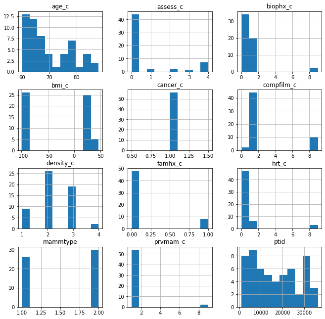

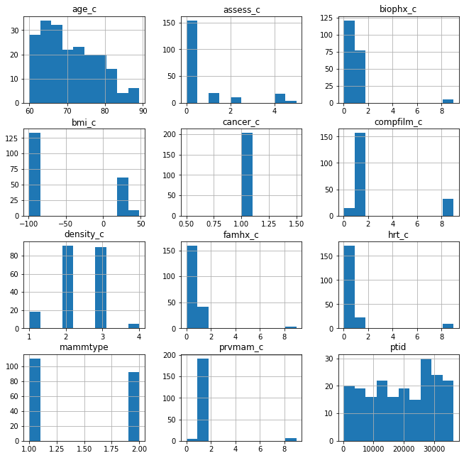

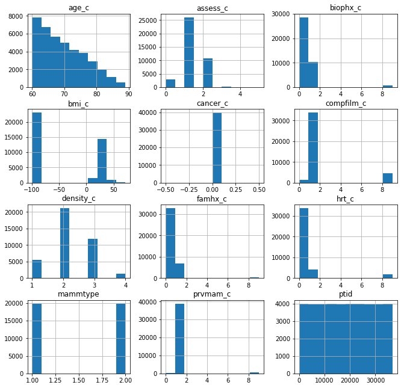

```python
dataset.groupby('CaTypeO').hist(figsize=(11, 11))
```

### Missing or Null Data points

```python
dataset.isna().sum()
```

```
age_c         0
assess_c      0
cancer_c      0
compfilm_c    0
density_c     0
famhx_c       0
hrt_c         0
prvmam_c      0
biophx_c      0
mammtype      0
CaTypeO       0
bmi_c         0
ptid          0
dtype: int64
```

```python
# replace Nil values with 9
dataset['bmi_c'] = dataset['bmi_c'].replace([-99], 9)
# Convert 8 placeholder to 0
dataset['CaTypeO'] = dataset['CaTypeO'].replace([8], 0)
# Merge positive cancer diagnosis, versus positive cancer types
dataset['CaTypeO'] = dataset['CaTypeO'].replace([2], 1)
# drop null values identified by the numeric value '9'
dataset = dataset[dataset.compfilm_c != 9]
dataset = dataset[dataset.famhx_c != 9]
dataset = dataset[dataset.hrt_c != 9]
dataset = dataset[dataset.prvmam_c != 9]
dataset = dataset[dataset.biophx_c != 9]
#dataset = dataset[dataset.bmi_c != 9]
# delete ptid column
del dataset['ptid']
# Print info again
dataset.info()
```

```
<class 'pandas.core.frame.DataFrame'>
Int64Index: 32772 entries, 0 to 39999
Data columns (total 12 columns):
 #   Column      Non-Null Count  Dtype
---  ------      --------------  -----
 0   age_c       32772 non-null  int64
 1   assess_c    32772 non-null  int64
 2   cancer_c    32772 non-null  int64
 3   compfilm_c  32772 non-null  int64
 4   density_c   32772 non-null  int64
 5   famhx_c     32772 non-null  int64
 6   hrt_c       32772 non-null  int64
 7   prvmam_c    32772 non-null  int64
 8   biophx_c    32772 non-null  int64
 9   mammtype    32772 non-null  int64
 10  CaTypeO     32772 non-null  int64
 11  bmi_c       32772 non-null  float64
dtypes: float64(1), int64(11)
memory usage: 3.3 MB
```

```python
dataset.groupby('CaTypeO').size()
```

```
CaTypeO
0    32577
1      195
dtype: int64
```

```
CaTypeO
0    [[AxesSubplot(0.125,0.725918;0.215278x0.154082...
1    [[AxesSubplot(0.125,0.725918;0.215278x0.154082...
dtype: object
```

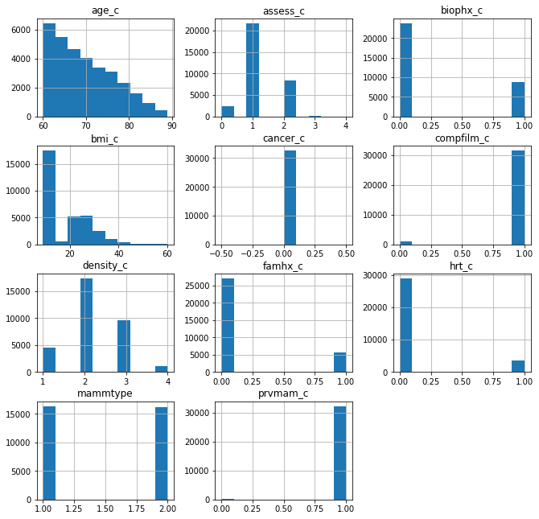

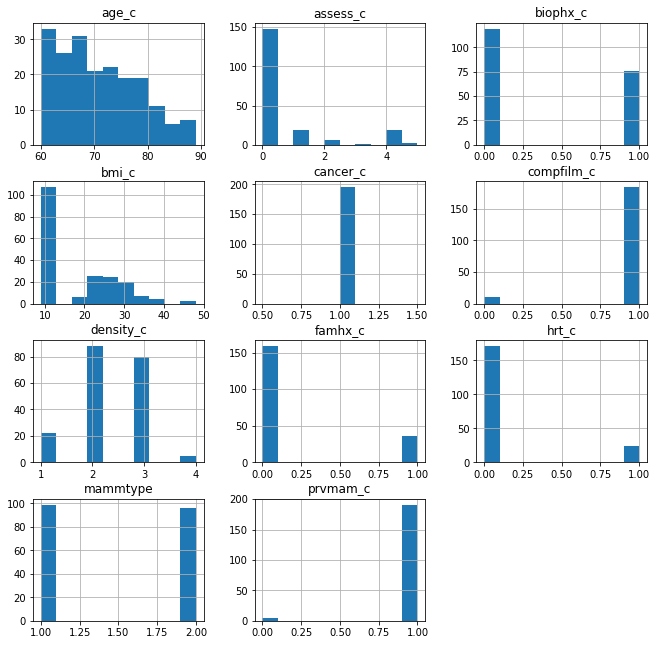

```python
dataset.groupby('CaTypeO').hist(figsize=(11, 11))
```

### Categorical Data

```python
# label encode categorical columns

lblEncoder_state = LabelEncoder()
lblEncoder_state.fit(dataset['assess_c'])
dataset['assess_c'] = lblEncoder_state.transform(dataset['assess_c'])

lblEncoder_cons = LabelEncoder()
lblEncoder_cons.fit(dataset['cancer_c'])
dataset['cancer_c'] = lblEncoder_cons.transform(dataset['cancer_c'])

lblEncoder_name = LabelEncoder()
lblEncoder_name.fit(dataset['compfilm_c'])
dataset['compfilm_c'] = lblEncoder_name.transform(dataset['compfilm_c'])

lblEncoder_party = LabelEncoder()
lblEncoder_party.fit(dataset['density_c'])
dataset['density_c'] = lblEncoder_party.transform(dataset['density_c'])

lblEncoder_symbol = LabelEncoder()
lblEncoder_symbol.fit(dataset['famhx_c'])
dataset['famhx_c'] = lblEncoder_symbol.transform(dataset['famhx_c'])

lblEncoder_gender = LabelEncoder()
lblEncoder_gender.fit(dataset['hrt_c'])
dataset['hrt_c'] = lblEncoder_gender.transform(dataset['hrt_c'])

lblEncoder_category = LabelEncoder()
lblEncoder_category.fit(dataset['prvmam_c'])
dataset['prvmam_c'] = lblEncoder_category.transform(dataset['prvmam_c'])

lblEncoder_edu = LabelEncoder()
lblEncoder_edu.fit(dataset['bmi_c'])
dataset['bmi_c'] = lblEncoder_edu.transform(dataset['bmi_c'])

lblEncoder_state = LabelEncoder()
lblEncoder_state.fit(dataset['biophx_c'])
dataset['biophx_c'] = lblEncoder_state.transform(dataset['biophx_c'])

lblEncoder_state = LabelEncoder()
lblEncoder_state.fit(dataset['mammtype'])
dataset['mammtype'] = lblEncoder_state.transform(dataset['mammtype'])
```

### Splitting the dataset

```python
target = dataset["CaTypeO"]
target_names = ["negative", "positive"]
data = dataset.drop("CaTypeO", axis=1)
feature_names = data.columns
data.head()
```

|  | age_c | assess_c | cancer_c | compfilm_c | density_c | famhx_c | hrt_c | prvmam_c | biophx_c | mammtype | bmi_c |
| --- | --- | --- | --- | --- | --- | --- | --- | --- | --- | --- | --- |
| 0 | 62 | 1 | 0 | 1 | 1 | 0 | 0 | 1 | 0 | 0 | 564 |
| 1 | 65 | 1 | 0 | 1 | 3 | 0 | 0 | 1 | 0 | 0 | 0 |
| 2 | 69 | 0 | 0 | 1 | 1 | 0 | 0 | 1 | 0 | 0 | 967 |
| 3 | 64 | 2 | 0 | 1 | 1 | 0 | 0 | 1 | 0 | 0 | 0 |
| 4 | 63 | 3 | 0 | 1 | 1 | 0 | 0 | 1 | 1 | 0 | 1291 |

```python
# separate train features and label
y = target
X = data

# split dataset into train and test data
X_train, X_test, y_train, y_test = train_test_split(X, y, test_size=0.33, shuffle=True, random_state=0)
```

[figure not shown]

### Feature Scaling

```python
sc = StandardScaler()
X_train = sc.fit_transform(X_train)
X_test = sc.transform(X_test)
```

### Model Selection

We used different types of classification algorithms:

1. Logistic Regression
2. Nearest Neighbor
3. Support Vector Machines
4. Kernel SVM
5. Naïve Bayes
6. Decision Tree Algorithm
7. Random Forest Classification

```python
#Using Logistic Regression Algorithm to the Training Set
# Create instance (i.e. object) of LogisticRegression
classifier = LogisticRegression(max_iter=1000)
# Fit the model using the training data
classifier.fit(X_train, y_train)
```

```
LogisticRegression(C=1.0, class_weight=None, dual=False, fit_intercept=True,
                   intercept_scaling=1, l1_ratio=None, max_iter=1000,
                   multi_class='auto', n_jobs=None, penalty='l2',
                   random_state=None, solver='lbfgs', tol=0.0001, verbose=0,
                   warm_start=False)
```

```python
y_pred = classifier.predict(X_test)
cm = confusion_matrix(y_test, y_pred)
trained_model=classifier.fit(X_train,y_train)
trained_model.fit(X_train,y_train )
print(cm)
print("Accuracy score of train Logistic Regression")
print(accuracy_score(y_train, trained_model.predict(X_train))*100)

print("Accuracy score of test Logistic Regression")
print(accuracy_score(y_test, y_pred)*100)
```

```
[[10754     0]
 [    0    61]]
Accuracy score of train Logistic Regression
100.0
Accuracy score of test Logistic Regression
100.0
```

```python
#Using KNeighborsClassifier Method of neighbors class to use Nearest Neighbor algorithm
from sklearn.neighbors import KNeighborsClassifier
classifier = KNeighborsClassifier(n_neighbors = 5, metric = 'minkowski', p = 2)
classifier.fit(X_train, y_train)
```

```
KNeighborsClassifier(algorithm='auto', leaf_size=30, metric='minkowski',
                     metric_params=None, n_jobs=None, n_neighbors=5, p=2,
                     weights='uniform')
```

```python
y_pred = classifier.predict(X_test)
cm = confusion_matrix(y_test, y_pred)
trained_model=classifier.fit(X_train,y_train)
trained_model.fit(X_train,y_train )
print(cm)
print("Accuracy score of train Nearest Neighbor")
print(accuracy_score(y_train, trained_model.predict(X_train))*100)

print("Accuracy score of test Nearest Neighbor")
print(accuracy_score(y_test, y_pred)*100)
```

```
[[10754     0]
 [    0    61]]
Accuracy score of train Nearest Neighbor
100.0
Accuracy score of test Nearest Neighbor
100.0
```

```python
#Using SVC method of svm class to use Support Vector Machine Algorithm
from sklearn.svm import SVC
classifier = SVC(kernel = 'linear',random_state = 0)
classifier.fit(X_train, y_train)
```

```
SVC(C=1.0, break_ties=False, cache_size=200, class_weight=None, coef0=0.0,
    decision_function_shape='ovr', degree=3, gamma='scale', kernel='linear',
    max_iter=-1, probability=False, random_state=0, shrinking=True, tol=0.001,
    verbose=False)
```

```python
y_pred = classifier.predict(X_test)
cm = confusion_matrix(y_test, y_pred)
trained_model=classifier.fit(X_train,y_train)
trained_model.fit(X_train,y_train )
print(cm)
print("Accuracy score of train Support Vector Machines")
print(accuracy_score(y_train, trained_model.predict(X_train))*100)

print("Accuracy score of test Support Vector Machines")
print(accuracy_score(y_test, y_pred)*100)
```

```
[[10754     0]
 [    0    61]]
Accuracy score of train Support Vector Machines
100.0
Accuracy score of test Support Vector Machines
100.0
```

```python
#Using SVC method of svm class to use Kernel SVM Algorithm
from sklearn.svm import SVC
classifier = SVC(kernel = 'rbf', random_state = 0)
classifier.fit(X_train, y_train)
```

```
SVC(C=1.0, break_ties=False, cache_size=200, class_weight=None, coef0=0.0,
    decision_function_shape='ovr', degree=3, gamma='scale', kernel='rbf',
    max_iter=-1, probability=False, random_state=0, shrinking=True, tol=0.001,
    verbose=False)
```

```python
y_pred = classifier.predict(X_test)
cm = confusion_matrix(y_test, y_pred)
trained_model=classifier.fit(X_train,y_train)
trained_model.fit(X_train,y_train )
print(cm)
print("Accuracy score of train Kernel SVM")
print(accuracy_score(y_train, trained_model.predict(X_train))*100)

print("Accuracy score of test Kernel SVM")
print(accuracy_score(y_test, y_pred)*100)
```

```
[[10754     0]
 [    0    61]]
Accuracy score of train Kernel SVM
100.0
Accuracy score of test Kernel SVM
100.0
```

```python
#Using GaussianNB method of naïve_bayes class to use Naïve Bayes Algorithm
from sklearn.naive_bayes import GaussianNB
classifier = GaussianNB()
classifier.fit(X_train, y_train)
```

```
GaussianNB(priors=None, var_smoothing=1e-09)
```

```python
y_pred = classifier.predict(X_test)
cm = confusion_matrix(y_test, y_pred)
trained_model=classifier.fit(X_train,y_train)
trained_model.fit(X_train,y_train )
print(cm)
print("Accuracy score of train Naive Bayes")
print(accuracy_score(y_train, trained_model.predict(X_train))*100)

print("Accuracy score of test Naive Bayes")
print(accuracy_score(y_test, y_pred)*100)
```

```
[[10754     0]
 [    0    61]]
Accuracy score of train Naive Bayes
100.0
Accuracy score of test Naive Bayes
100.0
```

```python
#Using DecisionTreeClassifier of tree class to use Decision Tree Algorithm

from sklearn.tree import DecisionTreeClassifier
classifier = DecisionTreeClassifier(criterion = 'entropy', random_state = 0)
classifier.fit(X_train, y_train)
```

```
DecisionTreeClassifier(ccp_alpha=0.0, class_weight=None, criterion='entropy',
                       max_depth=None, max_features=None, max_leaf_nodes=None,
                       min_impurity_decrease=0.0, min_impurity_split=None,
                       min_samples_leaf=1, min_samples_split=2,
                       min_weight_fraction_leaf=0.0, presort='deprecated',
                       random_state=0, splitter='best')
```

```python
y_pred = classifier.predict(X_test)
cm = confusion_matrix(y_test, y_pred)
trained_model=classifier.fit(X_train,y_train)
trained_model.fit(X_train,y_train )
print(cm)
print("Accuracy score of train Decision Tree Algorithm")
print(accuracy_score(y_train, trained_model.predict(X_train))*100)

print("Accuracy score of test Decision Tree Algorithm")
print(accuracy_score(y_test, y_pred)*100)
```

```
[[10754     0]
 [    0    61]]
Accuracy score of train Decision Tree Algorithm
100.0
Accuracy score of test Decision Tree Algorithm
100.0
```

```python
#Using RandomForestClassifier method of ensemble class to use Random Forest Classification algorithm

from sklearn.ensemble import RandomForestClassifier
classifier = RandomForestClassifier(n_estimators = 10, criterion = 'entropy', random_state = 0)
classifier.fit(X_train, y_train)
```

```
RandomForestClassifier(bootstrap=True, ccp_alpha=0.0, class_weight=None,
                       criterion='entropy', max_depth=None, max_features='auto',
                       max_leaf_nodes=None, max_samples=None,
                       min_impurity_decrease=0.0, min_impurity_split=None,
                       min_samples_leaf=1, min_samples_split=2,
                       min_weight_fraction_leaf=0.0, n_estimators=10,
                       n_jobs=None, oob_score=False, random_state=0, verbose=0,
                       warm_start=False)
```

```python
y_pred = classifier.predict(X_test)
cm = confusion_matrix(y_test, y_pred)
trained_model=classifier.fit(X_train,y_train)
trained_model.fit(X_train,y_train )
print(cm)
print("Accuracy score of train Random Forest Classification")
print(accuracy_score(y_train, trained_model.predict(X_train))*100)

print("Accuracy score of test Random Forest Classification")
print(accuracy_score(y_test, y_pred)*100)
```

```
[[10754     0]
 [    0    61]]
Accuracy score of train Random Forest Classification
100.0
Accuracy score of test Random Forest Classification
100.0
```

### Predictions

```python
models=[LogisticRegression(max_iter=1000),KNeighborsClassifier(),SVC(kernel = 'linear'),SVC(kernel = 'rbf', random_state = 0),GaussianNB(),DecisionTreeClassifier(),RandomForestClassifier()]
for model in models:
    score = cross_val_score(model,X,y)
    print("Accuracy: %0.3f (+/- %0.2f)" % (score.mean(), score.std() * 2))
```

```
Accuracy: 1.000 (+/- 0.00)
Accuracy: 0.994 (+/- 0.00)
Accuracy: 1.000 (+/- 0.00)
Accuracy: 0.994 (+/- 0.00)
Accuracy: 1.000 (+/- 0.00)
Accuracy: 1.000 (+/- 0.00)
Accuracy: 1.000 (+/- 0.00)
```

After applying the different classification models, we have get the below accuracies with the different models:

1. Logistic Regression — 100.0%
2. Nearest Neighbor — 99.4%
3. Support Vector Machines — 100.0%
4. Kernel SVM — 99.4%
5. Naive Bayes — 100.0%
6. Decision Tree Algorithm — 100.0%
7. Random Forest Classification — 100.0%

```
Confusion matrix, without normalization
[[8148    0]
 [   0   45]]
Normalized confusion matrix
[[1. 0.]
 [0. 1.]]
```

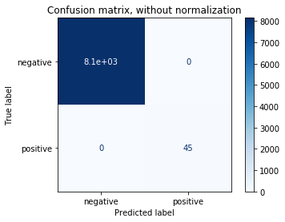

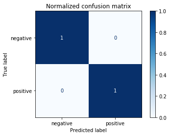

```python
# Split the data into a training set and a test set
X_train, X_test, y_train, y_test = train_test_split(X, y, shuffle=True, random_state=0)

# Run classifier, using a model that is too regularized (C too low) to see
# the impact on the results
classifier = svm.SVC(kernel='linear', C=0.01).fit(X_train, y_train)

np.set_printoptions(precision=1)

# Plot non-normalized confusion matrix
titles_options = [("Confusion matrix, without normalization", None),
                  ("Normalized confusion matrix", 'true')]
for title, normalize in titles_options:
    disp = plot_confusion_matrix(classifier, X_test, y_test,
                                 display_labels=target_names,
                                 cmap=plt.cm.Blues,
                                 normalize=normalize)
    disp.ax_.set_title(title)

    print(title)
    print(disp.confusion_matrix)

plt.show()
```

```python
from sklearn.svm import SVC
model = SVC()
from sklearn.model_selection import GridSearchCV
param_grid = {'C': [1, 5, 10],
              'gamma': [0.0001, 0.001, 0.01]}
grid = GridSearchCV(model, param_grid, verbose=3)
grid.fit(X_train, y_train)
```

```
Fitting 5 folds for each of 9 candidates, totalling 45 fits
[CV] C=1, gamma=0.0001 ...............................................
```

```
[Parallel(n_jobs=1)]: Using backend SequentialBackend with 1 concurrent workers.
```

```
[CV] ................... C=1, gamma=0.0001, score=0.994, total=   0.8s
[CV] C=1, gamma=0.0001 ...............................................
```

```
[Parallel(n_jobs=1)]: Done   1 out of   1 | elapsed:    0.7s remaining:    0.0s
```

```
[CV] ................... C=1, gamma=0.0001, score=0.994, total=   0.9s
[CV] C=1, gamma=0.0001 ...............................................
```

```
[Parallel(n_jobs=1)]: Done   2 out of   2 | elapsed:    1.6s remaining:    0.0s
```

[output not shown]

[output cut: 30 more lines]

[output not shown]

```
[Parallel(n_jobs=1)]: Done  45 out of  45 | elapsed:  1.2min finished
```

```
GridSearchCV(cv=None, error_score=nan,
             estimator=SVC(C=1.0, break_ties=False, cache_size=200,
                           class_weight=None, coef0=0.0,
                           decision_function_shape='ovr', degree=3,
                           gamma='scale', kernel='rbf', max_iter=-1,
                           probability=False, random_state=None, shrinking=True,
                           tol=0.001, verbose=False),
             iid='deprecated', n_jobs=None,
             param_grid={'C': [1, 5, 10], 'gamma': [0.0001, 0.001, 0.01]},
             pre_dispatch='2*n_jobs', refit=True, return_train_score=False,
             scoring=None, verbose=3)
```

```python
print(grid.best_params_)
print(grid.best_score_)
predictions = grid.predict(X_test)
from sklearn.metrics import classification_report
print(classification_report(y_test, predictions,
                            target_names = ["negative", "positive"]))
```

```
{'C': 10, 'gamma': 0.01}
0.997152032063385
              precision    recall  f1-score   support

    negative       1.00      1.00      1.00      8148
    positive       1.00      0.56      0.71        45

    accuracy                           1.00      8193
   macro avg       1.00      0.78      0.86      8193
weighted avg       1.00      1.00      1.00      8193
```

[Tableau visualization](https://public.tableau.com/profile/taylor.rotsted#!/)

[figure not shown]

*Data collection and sharing was supported by the National Cancer Institute-funded Breast Cancer Surveillance Consortium (HHSN261201100031C). You can learn more about the BCSC at: http://www.bcsc-research.org/.*